# Session One: Getting to Know R and RStudio

By Hellen Gakuruh

18 January 2017

## Session Goal

The main goal of this session is to facilitate you with the necessary tools and skills needed to begin working with `R` and `RStudio`.

## What we shall cover

By the end of this session you should:

- know the difference between `R` and `RStudio`
- have R and RStudio installed on your PC
- have an understanding of what is meant by; `R session`, `workspace/global environment`, `working directory`, `errors`, `warning` and `messages`
- be able to work interactively with both R and RStudio
- be able to write reproducible scripts
- know what packages are and where to get them
- be conversant with R libraries and how to add them
- be able to install and load a package

**Some Pointers on write-up**

Blocked content (with grey or white background and grey border) are called **R Chucks** which are R codes written you would write a script. The **#** symbol indicates a comment usually used to give information about some line of code and **##** indicates results or output of code which has been `rendered`.

If you are not totally new to R, how about skipping to the Gauge yourself section and see what you need to brush up on.

## What is R?

### Defining R and tracing it’s history

R is many things, if you have never used a statistical package or are new to data analysis and indeed statistical programming (for whom these tutorials are geared towards), begin by viewing R as a calculator that can perform numerous analysis. If you have been using other statistical packages more so using the ‘drop-down-menu/click’ method, view R as your tool for reproducible analysis (a growing concern in publications and evidence based programming in the development and humanitarian sectors).

More specifically, R is a statistical computing and graphics program. It is a dialect of **S** programming language developed by Ross Ihaka and Robert Gentleman in `1993`. It is partly named after these two leading founder’s first names and partly in conformity to the “one-letter” names of other programming languages developed at the `Bell Laboratories` of which `S` is one of them. The two founders developed the program while teaching at Auckland University in New Zealand. Their main aim was to offer their students a free statistical program they could use during their statistical class.

R as an implementation of the S programming language has much of the S code but with subtle difference, like lexical scoping which we shall discuss in detail in level two.

Over the years, R has grown from the little known statistical programming language used by a few university students in Auckland, to a widely used program applicable not only in academia, but also in other industries. It is currently being maintained by `R's development core group`. John Chambers, the founder of the S language is one of the core group members. Check out this page for current ratings for most statistical programs.

With the growing interest in R, there have been other programs developed with R as its base. Most of these are known as `Intergrated Development Environment (IDE)` that essentially help analysts and programmers to code more efficiently (IDE’s make R more user-friendly). The most widely used IDE’s include RStudio and Revolution Analystics. To distinguish R from the other programs, it is often called **base R** as it is the base for all the other programs. Just to clarify these two terms (`base` and `IDE`), you cannot have an IDE like RStudio without base R; base R is literally the foundation.

So in these tutorial series we shall refer to R as `base R` and we shall only work with `RStudio`, as it is suitable for an introductory session in R, it’s also as free as base R (but there is a commercial version).

### Downloading and Installation of Base R

R is freely available for downloading from `Comprehensive R Archives Network (CRAN)`. CRAN is R’s repository or a web server that stores identical and up to date version of its programs, codes and documentations.

#### Downloading the executable program

Before downloading, you will need to select one of CRAN’s mirrors. A mirror as the name suggests is a reflection (copy) of the original. In this case, there are numerous CRAN mirrors located around the world (you can select the one that is closest to you). The main purpose of these mirrors is to reduce network overload to the main server located at Institute for Statistics and Mathematics of WU (Wirtschaftsuniversit?t Wien), Austria.

Once you have selected a mirror you will then need to select a version suitable for your operating system: Windows, Mac, and Linux. Click on “install R for the first time” and it should start to download the most current version of R.

#### Installing Base R

When downloading is complete, click on the executable program which should be at the status bar or your downloads folder, then click run. This should take you through the following installation windows:

- The set-up language window where you choose the installation language you are most comfortable with.
- A welcome screen detailing the R version being installed. It also requests that all other applications should be closed for the installation process
- The license window which you can read before proceeding to the next installation window
- A window to indicate where R will be installed, the default is usually fine but you can change it if you are conversant with program installation and access.
- Next is a window to select the components to be installed. The first component should be selected as it contains core files. The next two depend on your system, but R should be able to detect it.
- A start-up options window which you can either let R set or you can customize it. If you select to customize it, then you will get a window indicating the start up menu folder. Here you can choose the default to have it in the R folder or you can specify another location. You can also indicate that the start-up menu should not be created; however, it’s best to choose the default.
- Next, you will need to indicate additional tasks to be performed during setup like creating a desktop icon, quick launch and registry files. If you will be using R often, you can click on the desktop or the quick launch options, but make sure to check the registry option as it is vital in R; and with that, installation should begin.

I am currently working on a quick instructional demo on how to install R on a windows operating system, please keep checking the demo page.

### Tour of base R

Now that you have installed R, let’s get to know it. First locate the installed program either from the desktop, on the start menu or if on `Windows` clicking `All Programs` and search for R. Once you have located it, click on the program to start it. The first screen you see would look like this:

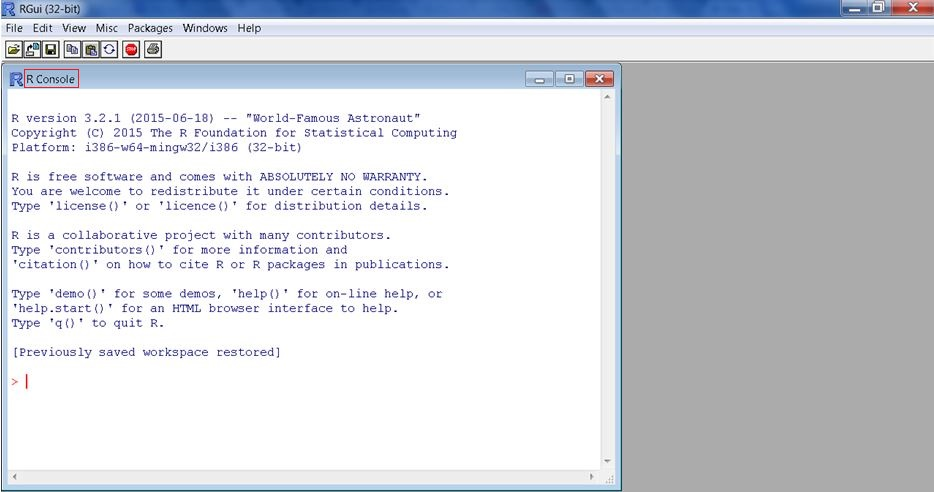

Base R

#### R at a glance

The first thing you notice are two windows; the main one with a menu bar and with a grey background and another window which has only the minimize, maximize and close buttons (an embedded window).

The embedded window is called the `R Console` and it’s R’s interactive platform for issuing commands (functions) which instantly produces an output similar to that of a normal calculator (type in values with the necessary computations and you receive instant results). The console is best suited for computations or expressions that can fit in one line, something like addition, subtraction, multiplications, and divisions or any other simple computation. For multiple line computations like writing your own commands or functions, scripts, are more suitable.

But before you get to type in your commands, there are a few (blue colored) introductory messages that give more information about the R version you have just installed; copyright issues; your computer’s platform; warranty and conditions for use; R as a collaborative package; recommended citation and some start-up commands or functions.

Let’s explore some of these commands as an introduction to R’s console (interactive session) before we venture into the menu bar which discusses a number of issues to do with the console and other R windows. Commands are issued or typed right after the (red) blinking cursor (`>` on windows, although this can be changed with the `options` function).

#### First interactive session on base R

One of the commands given in the introductory message is about the names of R contributors. Since R is a free program, it is generally developed and maintained by volunteers, for this reason it would be good to see some of the good people who have given us such a wonderful program for free. To do so, type `contributors()` and don’t forget the two parentheses `()` which indicate a command or a function call (as we shall soon learn).

```r
## Type
contributors()
```

Hoping your first line of code worked. If it did, you should see a new window with some write-up on the contributors and a bit of history and inspiration that led to R’s development. If you received an error, please check your spelling and case: `R is case sensitive` and any slight `misspelling` would not yield expected results.

So now we can say you have written your first command in R also known as `making a function call`: a great achievement. We will be discussing function calls in the next session but what you should know right now is that parenthesis in `R` indicate a function, therefore the name before the `()` is the name of the function you wish to use like `mean` is a name and it is a function because it is followed by `()`. We say `function call` when you use a function or what you might call a command in other programs, for example when we use the mean function `mean(c(2, 5, 6, 9, 3))` we have made a function call.

For our next function call, let’s bring up the help documentation by typing `help.start()` (please note the `.` between the two words). If you typed it correctly, then you will see a window titled `Statistical Data analysis`, below it are four subheadings namely `manuals`, `references`, `miscellaneous materials` and `materials specific to your operating system`. The `help.start()` function is a great reference point and you should consult it frequently as you learn R. I strongly advice you read the manual on `Introduction to R` alongside this tutorial posts. Word of encouragement, most of the details might not be clear right now as you have really not had a go at R, but after a few sessions you will be able to appreciate the details in these documents).

Two final commands that might be useful at this very early stage are clearing the console and quitting R from the command line. Your console right now has quite bit of information (`introductory message`, `contributors()` and `help.start()`), if you would like a blank/clear screen to type on, press `control(Ctrl) and L` together if you are on windows and you should have a blank screen. Everything that was on the console should be cleared from the screen but not from history. R by default saves commands you issue and can be recovered from the history file. To quit R, one way is to use the command line by typing `q()` (try it and log in again).

With that, you have successfully experienced R and are ready to do more, but first, you need to acquaint yourself with two other windows. The first is what is called the `workspace` or the `global environment` and the `script window`.

#### R’s other core windows

##### The Workspace/Global Environment Window

As you get to work with R, you will soon discover that everything entity in R is referred to as an `object`, from the data to the functions, to use any of this objects they need to be in an `environment` that R can access. This means for example that data has to imported into R as well as functions you have developed. These objects are usually temporary stored in what is called the **workspace** or **global environment**. In base R, the `workspace/global environment` is an invisible window whose content can be inspected by a call to `objects()`, or `ls()`. It is a temporary storage area for your objects and it is the first place R goes to look for objects during execution of functions.

Try calling either of these two functions (objects/ls), they should return `character(0)` meaning there is no object you have imported or created so far. Later once we have learnt assignment operators you will be able to see your objects with this these functions or remove them with `rm()`.

##### The script window

When working interactively on the console, you are literally issuing commands without saving them. You can recall a function using a history file but sometimes you would want to have all the code in one prose which you can rerun some sections or all of it. R (an indeed many other programming languages) offers something called a **script** which is a text editor where you can write the commands/codes, this is usually written in a new window called “R Editor”. A script written in this editor can be saved with a `.R` extension and can be retrieved later. Read more about scripting below.

#### R’s menu bar

Okay, let’s go to the menu bar, where you will notice the following menu items; `File`, `Edit`, `View`, `Misc`, `Packages`, `Windows` and `Help`. Our aim here is not to dissect each of the menu item but rather have a basic knowledge as most will become relevant and clear once you start to work with R.

- From the **file** menu item, several options are provided to begin working with R.
  - The first, “Source R Code” is used to open an existing script that is saved as a source file. A source file is used to store related objects like functions or data. They can be called from another file/console in which case its contents are loaded on the `workspace`. Another way to access this file is by calling the `source()` function with the name of the file e.g. `myAnalysis.R`. added between the two parenthesis
  - The next one offer’s you the chance to start a new script,
  - The third menu “open script” is more like the first, only that in this case the script is not a source file therefore its contents have to be run individually.
  - You can also open a script by Displaying files which is different from `open script` as you open any file other that R scripts which end with `.R` extension
  - Next you can load or save a workspace or a history file. A workspace as earlier mentioned is a temporal storage for your objects. This can be saved by calling the `save() or save.image()` functions or loaded with a call to `load()` function. History files can also be saved and loaded using `savehistory()` or `loadhistory()`. Within the parenthesis should be the `file name (including its extension ".Rdata" or ",Rhistory")`, if there is no file name given, R will save the files with only the extension on your working directory.
  - You can also change your directory, a directory here means the `Working directory` which is a folder to be used to save files or has files for your R session. It’s important to always tell R what folder you will be using as it will source or store objects in that directory/folder. This folder can change as you work with different R assignments/tasks.
  - Next is the `print` where you can send your file to be printed
  - You can save console activity with save to file
  - Finally you can `exit` R in which case you would be prompted to save you `workspace` and other unsaved files before exiting.
- Next to the file is **Edit**, with most of it contents clear and only needs demonstration on how to use them. However, the last item GUI preferences might need a bit more discussion but let’s do this a bit later when more ground work has been covered. It used to change setting of some of R’s appearance, for now it is not important and the default is okay.
- The **view** menu item can be used to specify if you what the toolbar and/or the status bar. Try checking and unchecking them and see.
- The **Misc** are R commands for stopping computation, buffering (temporary storing on the disk for activities taking different time) an output, word completion, listing objects, removing all objects and checking R search paths.
- The next item is the **“packages”** which we shall discuss in detail.
- **Windows** just indicates how you would like the windows to be arranged. It works the same way as when you have multiple windows open and want them to be ordered in a certain way.
- The last tool is the **help** menu which lists a number of ways one can get help. We shall be discussing this in details below.

#### R remembers

Every you do on the console or run from a script is temporary captured and stored by R. So if you do some computation or analysis, R will remember it and can retrieve it. For example,

```r
# Compute the following:
1 + 5
## [1] 6
10 + 102
## [1] 112
```

Suppose you want to redo the computation, you can recall the computation with the “up” and “down” arrow keys and you can edit them as need be.

This is referred to as **history** and it is capture by R in **.Rhistory** file. On exit, by default this history file is saved in your working directory. This means that the next time you start R from that working directory the history file will be automatically loaded and you can recall any function used previously.

#### R session

Before winding up this brief tour of R, it’s important to note one useful term that you will hear quite a bit of and that `R session`. A session in R begins when you start-up R and ends when you close the program; this is important to know as it has certain implications. For example, everything you do during an R session is recorded or documented in a history file which as noted earlier can easy be save or retrieved.

NB. All quite a bit of this might not be clear right now, but it will definitely become clear when you have defined some few variables or objects or simply when you have started working with R both at the console (interactively) or on a script.

Now let’s wind this section with a bit of computation on the console.

### Interactive Session (working with base R’s console)

On the console right after the blinking cursor (just as we did during our tour of R), perform the following simple arithmetic, something you would normally do on a calculator:

```r
# Addition
2 + 5
## [1] 7
# Subtraction
4 - 10
## [1] -6
# Division
30/2
## [1] 15
# Multiplication
3 * 9
## [1] 27
```

Note that in this case, the mathematical operators are now functions that carry out the computation, otherwise you can call other R functions that do the same computation like `sum()` for addition or you can develop your own function (which we shall discuss in the second level).

Moving on, suppose we wanted to find even numbers or whether a number is divisible by another number. For example, what would you expect if you divided an even number with 2? Yes, indeed, you should get a whole number without any remainder or a point. An odd number would have a 0.5 remainder. Let’s test this:

```r
# Even Numbers
#-------------
2/2
## [1] 1
4/2
## [1] 2
6/2
## [1] 3
20/2
## [1] 10
100/2
## [1] 50
100000000000000000000000000/2 # An even long number produces an exponent
## [1] 5e+25


# Odd numbers
#------------
5/2
## [1] 2.5
35/2
## [1] 17.5
37/2
## [1] 18.5
```

We can use this same logic, to compute divisibility of any number by another. If by dividing we get a remainder, then the number is not divisible by the other number. If on the other hand we got a full number without any remainder, then the number is divisible by the other. Let’s work it out on our new calculator (R console).

```r
# Divisible numbers
#----------------
10/5
## [1] 2
100/20
## [1] 5
1700/17
## [1] 100


# Not divisible
#-------------
59/3
## [1] 19.66667
60/9
## [1] 6.666667
25/2
## [1] 12.5
70/3
## [1] 23.33333

# Try out other numbers
```

Now, that was good, but there is a way to quickly determine divisibility by using what is called **modulo**. Given two integers, modulo (indicated by two percentages **%%**) checks to see whether the integer on the left of it is divisible by the integer on the right. **Modulo returns the remainder of the division** such that if a number is divisible by another then we expect no remainder and therefore results to a zero.

For example, if we have 9 and 3, we could use modulo like this, **9%%3**. In this case we are asking **is 9 divisible by three?**. So, if 9 is divisible by 3 then we expect a zero meaning there was nothing that remained after the division but if it were not the case, then we would expect to get the remainder of the division.

```r
9 %% 3
## [1] 0
```

In Mathematics, for our example, 9 is referred to as the **dividend** and 3 as the **divisor**. If we had **9%%2** we expect a remainder of 1 where 9 is the dividend and 2 the divisor. When you divide 9 by 2 you get 4 and a remainder of one resulting in 4.5. In this case, the number 4 is referred to as the **quotient** and 1 the **remainder**. There is a whole discussion on this topic; but here I am merely introducing you to the concept which you could use in your programming.

Now let’s test it:

```r
9 %% 3
## [1] 0

15 %% 7; 15/7
## [1] 1
## [1] 2.142857

# How about long numbers (at least one that you cannot figure out)
69294797 %% 8 # It says the remainder is 5
## [1] 5

# Let's confirm this
69294797/8 # Opps, we have a whole number, what is R up to?
## [1] 8661850

# R has default number of digits it can print, if your output exceed it like ours, then R will round it off to its default digit (in my case it is 7). To see your default:
getOption("digits")
## [1] 7
# and to change it
options(digits = 9)
# Now let's rerun our command
69294797/8 # we have our remainder (though not exactly 5 -- discussion for another session)
## [1] 8661849.62
```

Now, let’s briefly compute the mean (a measure of a data’s centrality) and see the number of ways we can do it.

What is the average of the following numbers?

```
        * 2, 5, 9, 3
        * 5, 8, 10, 100
```

There are two ways you can do this (at least for a small amount of data), the first entails adding the values and then dividing with their totals just like a calculator, or the r way by using the **mean function**.

```r
#The calculator way
(2 + 5 + 9 + 3)/4
## [1] 4.75

#The R way
mean(c(2, 5, 9, 3))
## [1] 4.75
```

Notice that R’s way is simpler and can handle many numbers. But we had to enclose the numbers in parenthesis with a letter `c` at the front. `c` is a function that means `combine` (the values). We shall discuss this concept further during the vectorisation session but for now, use `c(your values here)` whenever you want to compute the mean of some values.

I encourage you to get hold of some useful (numerical) data like the ages of your colleges or friends, class scores, hair/eye color in your area or some budget data and compute their average on the console. That should give you a good start to interacting with R.

At this point you have been able to make some few function calls, at least commands R understands and can get you results. Question is, what if R does not understand what you are asking? Or what if R does not have the information needed? Or there are either problems or other execution information. These are typical issues in any analytical program and there are ways of dealing with them. In R, you would most often receive an `error` a `warning` or a `message`. Let’s look at these terms as they would become quite frequent especially at this early stage.

#### Errors, Warnings and messages

##### Errors

Suppose you asked R to do something with a function that does not exist; like get an average of some data but you misspell the function name by typing `means()` instead of `mean()`. What do you think would happen?

```r
means()
```

R would go looking for what you have typed (means) and not what you meant (mean), so unless there is another function by that name, R would not find what you sent it out to get. When this happens R would **throw and error** that it could not find the function.

```r
means()
#Error: could not find function "means"
```

An error therefore appears when R cannot find what you have asked it to get. Visualize it this way, you type in a command and hit enter; R then gets hold of your command and goes on a search for the description of the command or the actions the command should do (later on, you will learn Rs search path). This search begins from your workspace followed by other areas called enclosing environments, the last of these environments being **Base R**. If the command is not found there, it hits the **empty environment** where no object exists and therefore sends you the error: R does the same thing when looking for data.

Note R literally `stops` the execution of the command and then sends you the error message: it’s a `failure to launch` scenario.

##### Warnings

What if you gave R a command it can find, but in this case you have used it incorrectly or there is a more effective command or simply put, there are potential problems with your function call. R would execute the command but issue a `warning message` indicating execution problems faced.

Key point here is that R will execute the function subject to the identified problems which it will detail as warning messages. For example, when you what to use an integer (as opposed to a numeric value), you have to tell R the value is an integer by using the letter **L** after the value. If you mistakenly add a decimal point before the letter L, then you will get a warning message.

```r
# Unnessary use of a decimal point
1.L
## [1] 1
## Warning message:
## integer literal 1.L contains unnecessary decimal point

# Otherwise it should have been
1L
```

##### Messages

Messages are informative statements given with R output/results. They usually give information on how execution was performed and these do not signal a problem just procedures used in the execution.

For example, if there are missing values or method in a call, `R` can execute the function but issue a message indicating what value or method was used.

## RStudio

R Studio is a more user friendly version of R, and one of R’s growing Integrated Development Environment(IDE)’s. It includes a console, syntax-highlighting editor that supports direct code execution, as well as tools for plotting, history, debugging and workspace management “https://www.rstudio.com/products/rstudio/”.

Note we will be using RStudio for the rest of these tutorial series.

### Downloading and Installing RStudio

To download the latest version of the program, go to RStudio and select a program suitable for your computer’s specification.

There is an open source and a commercial version running on Windows, Mac, or Linux. You can also get the desktop version of Rstudio or Server version. Read more on the differences and varieties of Rstudio here.

Keep checking this page for an upcoming demo showing the step by step process of downloading and installing Rstudio.

### Getting to know RStudio layout

Once you have installed the program and clicked to start it, you will immediately notice four windows called panes. Let’s begin with one pane you are now familiar with; the console (usually located at the bottom left, though it can be in any side).

[figure not shown]

Rstudio Interface

You can start using it just as you did with `base R's` console and see if you can get the same results.

Right above the console is the `script pane` which is a scripting window. If you can not see it, start a new script by clicking on `files`, then `New File`. For now select the first file type, R script, we shall discuss the other types of files during reproducible analysis session.

[figure not shown]

Rstudio Interface

On the top right side, is a window with two tabs, the first tab is called the `environment` and it is basically the workspace we discussed earlier. Next tab is the history window which captures commands and variables created during a session. These two tabs play an important role in storage and retrieval of your data and functions.

Below the workspace is a pane with five tabs. The first is the `files tab` which shows you the folders and files in the working directory. Next to it is the `plotting window` where graphs are displayed. The `packages tab` follows and shows the packages/R extensions that are currently available on your system. Following the packages tab is the `help tab` where R’s help documentation is shown. Finally is the `viewer pane`, it is used to extend Rstudio to view internet local content more so related to applications such as `Shiny` which we will briefly mention later.

Now with that quick tour of R Studio and since it shall be our learning platform, we shall not go into further details as we shall **learn on the go**.

### Working with RStudio’s console

R Studio’s console is exactly like that of base R. To prove this, try and rework the exercises done on base R.